# Analyzing the Spatiotemporal Dynamics of Dengue Fever in Merida, Mexico (2012–2015)

Aman Shaik, Nick Huberty, Tom Suo, Connor Lee

2025-10-23

### 1. Introduction

In this exploratory data analysis, our group examines dengue fever cases in the city of Mérida, Mexico, using data provided by Professor Clennon of the Emory Environmental Science Department. Dengue fever is a mosquito-borne viral infection caused by the dengue virus, which poses a significant public health concern in tropical and subtropical regions.

Some of dengue fever’s most common symptoms include sudden drops in blood pressure, nausea, and muscle pain. Researchers have found that Merida, the capital of the state of Yucatán, experiences recurrent dengue outbreaks due to its tropical climate, seasonal rainfall and standing water, and dense urban population density.

Our group is interested in public health, epidemiology, and the positive effect that well-developed data analysis can have on urban welfare. In part, this interest derives from our experiences with the COVID-19 pandemic and its widespread reporting on its pathology, treatment, and mitigation. Dengue Fever’s effects are similar to COVID-19’s, and the disease similarly impacts communities worldwide. However, its relatively slower spread and its prevalence predominantly in tropical areas with underdeveloped healthcare infrastructure have led to severe neglect compared to other dangerous diseases. This study is primarily an exercise in geospatial and temporal analysis of a viral disease.

Our dengue dataset includes 540 rows, each representing a distinct region within Mérida. Each region is quantified based on its coordinates from the Universal Transverse Mercator (UTM) system, a grid-based coordinate system used to map locations using meters. The dataset initially had 8 columns: the X and Y UTM coordinates of each region, SP_ID (an identifier for each region), CVEGEO (geographic identifier code used by the Mexican Geographic Agency), and the number of cases in each region across four different years (2012-2015). As we explain in the Data Cleaning step, SP_ID and CVEGEO are not necessary for our analysis here. Additionally, we have included complementary data on ovitrap egg density (the quantity of mosquito eggs recorded for 4177 ovitraps distributed throughout the city). Although it is not the main focus of our analysis, it provides some insight into potential examination of the relationship between mosquito breeding sites and dengue incidence.

### 2. Project Setup, Data Loading, and Data Cleaning

Before developing any visualizations or analytical models, we prepared the R environment by loading our primary dataset, “Merida_Den12_13_14_15.csv,” along with a complete suite of R packages. We used the tidyverse package, which provides core tools like dplyr for data transformation and ggplot2 for static visualization. For our more advanced interactive plots, we loaded plotly (used for the animated density map) and leaflet (used for the interactive Year-over-Year map). We also included sf to read and handle the simple features (geospatial) data for Merida. Once all libraries were loaded, we imported the dataset into a data frame. The resulting data frame contained 540 rows and 8 columns, representing spatial identifiers, coordinate values, and annual dengue case counts. This formed the foundation for our exploratory analysis.

Data Cleaning is a crucial step to ensure the integrity and relevance of the data prior to our analysis. We want to ensure that all the data required for this project is clean, validated, and standardized so that our group can create data visualizations using the shared data.

```r
if (!require("spdep")) install.packages("spdep")
```

```
## To access larger datasets in this package, install the spDataLarge
## package with: `install.packages('spDataLarge',
## repos='https://nowosad.github.io/drat/', type='source')`
```

```r
# Load Libraries
library(tidyverse) # Loads dplyr, ggplot2, readr, etc.
library(plotly)
library(leaflet)
library(sf)
library(htmltools)
library(scales)
library(spdep)

# Load Data
data <- read.csv('data/Merida_Den12_13_14_15.csv')
pop_data <- read.csv('data/merida_census_final.csv')

# Inspect Data
head(data)
```

```
##          X       Y SP_ID        CVEGEO Den2012 Den2013 Den2014 Den2015
## 1 231639.6 2317510     0 3104100010070      17       6       2       2
## 2 231323.1 2316622     1 3104100010085      35      15      10      18
## 3 230769.7 2316113     2 310410001009A      35      14       8      17
## 4 233250.8 2316208     3 3104100010136      40       8       6      10
## 5 233266.3 2317442     4 3104100010140      12       8       4       4
## 6 232736.6 2317238     5 3104100010155      30       8       1       5
```

```r
head(pop_data)
```

```
##         AGEB_ID Males Females X0.14.years X15.64.years X65..years  yes  no
## 1 3103600010155    52      55          38           66          3   64   5
## 2 3103600010136   932     936         479         1212        177 1241 148
## 3 3103600010102   826     806         409         1078        145 1046 177
## 4 3103600010085    50      56          29           73          4   65  12
## 5 3103600010121   639     682         324          912         85  904  93
## 6 310360001009A   909     852         426         1192        143 1211 124
##   Roman.Catholics Protestants No.religion Population Area Density
## 1              88           5          14         NA
## 2            1428         252         187         NA
## 3            1271         214         147         NA
## 4             100           6          NA         NA
## 5             963         210         146         NA
## 6            1379         223         158         NA
##   Other.religion
## 1             NA
## 2             NA
## 3             NA
## 4             NA
## 5             NA
## 6             NA
```

```r
# 1. Ensure the ID columns are characters to prevent scientific notation issues during joining
data <- data %>% mutate(CVEGEO = as.character(CVEGEO))
pop_data <- pop_data %>% mutate(AGEB_ID = as.character(AGEB_ID))

# 2. Join the datasets
# We keep all dengue records (left_join) and match CVEGEO to AGEB_ID
data_merged <- data %>%
  left_join(pop_data, by = c("CVEGEO" = "AGEB_ID"))

# 3. Calculate Incidence Rates (Cases per 10,000 people)
# We handle division by zero (if population is missing or 0)
data_cleaned <- data_merged %>%
  mutate(
    # Create Rate columns
    Rate2012 = (Den2012 / Population) * 10000,
    Rate2013 = (Den2013 / Population) * 10000,
    Rate2014 = (Den2014 / Population) * 10000,
    Rate2015 = (Den2015 / Population) * 10000
  ) %>%
  # Replace any Infs or NaNs (from 0 population) with NA
  mutate(across(starts_with("Rate"), ~ifelse(is.finite(.), ., NA))) %>%
  # Select only the columns we need for analysis
  select(X, Y, SP_ID, CVEGEO, Population, starts_with("Den"), starts_with("Rate"))

data_cleaned <- data_cleaned %>%
  filter(!SP_ID %in% c(392, 451))

# Check for nulls in the new rate columns
na_counts <- colSums(is.na(data_cleaned))
print("Missing values check:")
```

```
## [1] "Missing values check:"
```

```r
print(na_counts)
```

```
##          X          Y      SP_ID     CVEGEO Population    Den2012    Den2013
##          0          0          0          0         65          0          0
##    Den2014    Den2015    Density   Rate2012   Rate2013   Rate2014   Rate2015
##          0          0         65         70         70         70         70
```

```r
tail(data_cleaned)
```

```
##            X       Y SP_ID        CVEGEO Population Den2012 Den2013 Den2014
## 533 219331.0 2315431   534 3110100010475       2041      24       8       3
## 534 218650.4 2314692   535 311010001048A          0       0       0       0
## 535 213855.1 2311127   536 3110100010494       2180      66       8      10
## 536 213774.8 2310206   537 3110100010507       2637      24       6       8
## 537 212445.8 2312617   538 3110100010511         51       0       0       0
## 538 214621.0 2312714   539 3110100010526        124       3       1       0
##     Den2015   Density  Rate2012 Rate2013 Rate2014  Rate2015
## 533      24  4944/km² 117.58942 39.19647 14.69868 117.58942
## 534       0     0/km²        NA       NA       NA        NA
## 535      53  3852/km² 302.75229 36.69725 45.87156 243.11927
## 536      24  2346/km²  91.01251 22.75313 30.33750  91.01251
## 537       0  3622/km²   0.00000  0.00000  0.00000   0.00000
## 538       2 424.3/km² 241.93548 80.64516  0.00000 161.29032
```

### 3. Exploratory Analysis 1: Aggregate City-Wide Trends

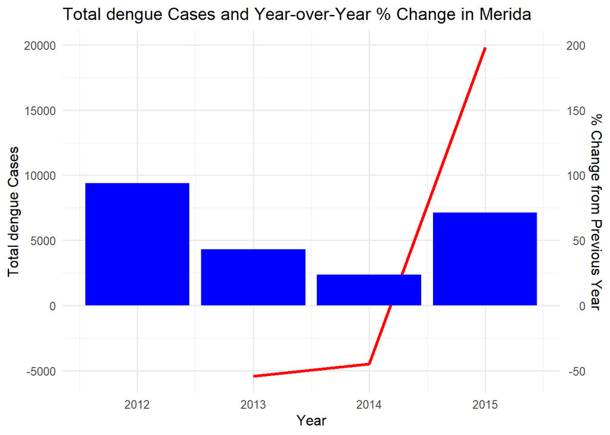

```r
### Reorganize the dataset so each year's dengue fever count is stored as a separate row
data_formatted <- data %>%
  pivot_longer(
    cols = starts_with("Den"),
    names_to = "Year",
    values_to = "Count"
  ) %>%
  mutate(Year = as.numeric(gsub("Den", "", Year)))

### Summarize the total dengue fever cases per year and calculate Year-over-Year percent change
data_summary <- data_formatted %>%
  group_by(Year) %>%
  summarise(
    total_dengue = sum(Count, na.rm = TRUE))%>%
  arrange(Year) %>%
  mutate(
    percent_change = (total_dengue - lag(total_dengue))/lag(total_dengue) * 100
  )

### Visualize total dengue fever cases per year and Year-over-Year percent change
ggplot(data_summary, aes(x = Year)) +
  geom_line(aes(y = percent_change * 100), color = "red", size = 1.2) +
  scale_y_continuous(
    name = "Total dengue Cases",
    sec.axis = sec_axis(~./100, name = "% Change from Previous Year")
  ) +
  geom_col(aes(y=total_dengue), fill = "blue")+
  theme_minimal(base_size = 12) +
  labs(
    title = "Total dengue Cases and Year-over-Year % Change in Merida",
    x = "Year"
  )
```

When it comes to diseases, outbreaks, and other public health concerns, it is crucial to monitor the volume of cases to understand if the outbreak is being contained. Starting off as simply as possible, we created a bar graph that summarizes the broader statistics of our dengue fever dataset in Merida – more specifically, we created a visualization that summarizes the amount of dengue fever cases from 2012 to 2015. This was conducted by grouping the cases by what year they were from, and then counting how many cases were in each year. The graph shows 2012 having the highest volume of dengue fever cases of almost 10,000, which has a significant dropoff in 2013. Following this trend, 2014 also sees a decline in total dengue fever cases, until another sharp increase of cases comes in 2015 of around 7,500 cases.

Despite being able to visually see the fluctuations in volume of dengue fever cases, our group decided to create a percent change, year-over-year, line visualization over the same chart. This method of calculating percent change is useful in tracking the rate of increase or decrease of the dengue fever, which allows us to not only understand the spread of the disease, but how quickly it is spreading. By using geom_line in our visualization, the red line helps our audience understand the relative changes in dengue fever cases over the years. When the percent change is sharply negative, like in 2013 and 2014, that could indicate successful containment plans, while sharp positive changes in the red line could signal a public health crisis.

The pertinence of this visualization is that it helps with public health tracking and surveillance. Despite being a more general statistical visualization, this graph can help track the trends of how quickly dengue fever is spreading in Merida, while also assessing the effectiveness of interventions in certain years, assuming that certain confounding variables are controlled for – other variables such as seasonal changes and weather variation could certainly impact our future findings. Ultimately, data tracking leads to action, and in the case of dengue fever, it can lead to mosquito control initiatives or vaccination campaigns.

This initial analysis provides a strong foundation for conducting a geospatial analysis on where these dengue fever cases are specifically occurring.

### 4. Exploratory Analysis 2: Ovitrap Data

Before we further analyze dengue incidence over time, let’s briefly look at some data for mosquito ovitraps. Ovitraps allow researchers to estimate the number of mosquitoes in an area by replicating breeding environments and measuring egg count. As dengue is a mosquito-borne illness, we should keep in mind the relative density of mosquito eggs as we look at disease hot spots later on. For the purposes of this analysis, we will not run statistical tests examining the exact association between estimated mosquito density and dengue incidence, as we intend to focus more on geospatial and temporal analytics.

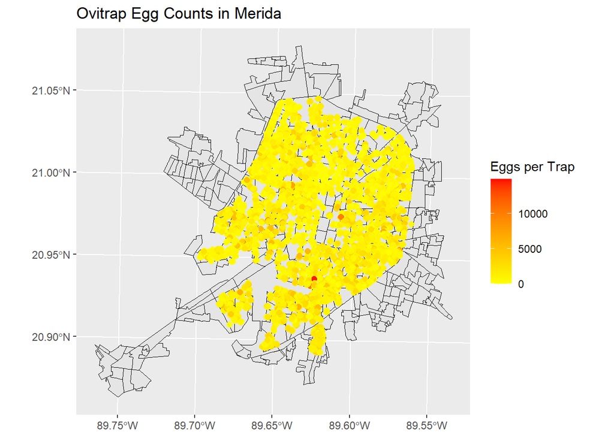

```r
map <- st_read("data/Merida_S25/Merida_Den12_13_14_15/Merida_Den12_13_14_15.shp")
ovitraps <- st_read("data/Merida_S25/Ovitraps_Sum/Ovitraps_Sum.shp")
# Create the plot with a gradient from yellow to red, representing relatively low to relatively high egg density. Overlay the plot on a blank regional map of Merida.
ggplot() +
  geom_sf(data = map, color = "black", linewidth = 0.3) +                         # Create map outline
  geom_sf(data = ovitraps, aes(color = Total), size = 2, alpha = 0.9) +           # Generate ovitrap points
  scale_color_gradient(low = "yellow", high = "red", name = "Eggs per Trap") +    # Add color gradient to represent eggs per trap
  labs(title = "Ovitrap Egg Counts in Merida")                                    # Add title
```

### 5. Exploratory Analysis 3: Animated Spatial-Temporal Trends

```r
# Reshape dataframe from wide to long format, each year becomes a separate row with 'Cases' column
data_long <- data_cleaned %>%
  pivot_longer(
    # CHANGE HERE: explicitly select the 4 year columns OR use a regex pattern
    cols = c(Den2012, Den2013, Den2014, Den2015),
    names_to = "Year",
    names_prefix = "Den",
    values_to = "Cases"
  ) %>%
  mutate(Year = as.integer(Year))

# Create animated scatter plot of dengue cases
fig <- plot_ly(
  data_long,       # use long-format dataframe
  x = ~X,
  y = ~Y,
  frame = ~Year,   # animate by year
  type = 'scatter',
  mode = 'markers',
  color = ~Cases,  # color by case count
  colors = "Reds", # color scale
  marker = list(
    size = 10,
    line = list(width = 0.3, color = 'black') # add thin black border
  ),
  # Add hover text with detailed info
  text = ~paste(
    "Year:", Year,
    "<br>Cases:", Cases,
    "<br>X:", round(X, 2),
    "<br>Y:", round(Y, 2)
  ),
  hoverinfo = 'text'
) %>%
  # Add color bar to indicate case counts
  colorbar(title = "Annual Case Count") %>%
  # Update layout, axis titles, and background colors
  layout(
    title = 'Dengue Fever Density in Merida (2012–2015)',
    xaxis = list(title = 'X Coordinate (UTM in Meters)'),
    yaxis = list(title = 'Y Coordinate (UTM in Meters)'),
    plot_bgcolor = "white",
    paper_bgcolor = "white"
  ) %>%
  # Set animation speed and transition style
  animation_opts(
    frame = 5000,      # 5 seconds per frame
    transition = 1500,  # 0.8 second transition
    easing = "linear"
  ) %>%
  # Add animation slider for selecting year
  animation_slider(
    currentvalue = list(
      prefix = "Year: ",
      font = list(color = "red")
    )
  )

fig
```

[interactive chart not shown]

We can further analyze the evolution dengue virus in the Merida region over a period of time with an animated density chart. By using Plotly, we can plot the position, measured in UTM coordinates (meters), of the annual case counts (2012-2015), allowing us to visualize high-density infected regions in red and low-density regions in white. The animation illustrates how the spatial distribution of the disease fluctuates across the same areas throughout the analyzed timespan.

When analyzing the density chart in 2012, we can see a significant outbreak as there are two primary hotspot regions with annual case counts exceeding 100. It is important to note that these hotspots are not isolated. They are surrounded by dengue-infested locations reporting nearly 50 annual cases, indicating a concentrated and widespread initial event.

If we advance to 2013, we can see a surprising city-wide reduction in Dengue Fever incidence. There are far fewer cases overall, with no single region in Merida reporting over 100 annual cases and only a handful approaching 50 cases. Overall, the area is dominated by low-incidence areas, suggesting the outbreak has died down. This trend continues into 2014, which shows an even more pronounced decline as the vast majority of regions report zero cases, and the most significant hotspot contains only around 30 cases.

However, in 2015, we can see a powerful resurgence. While many areas remain low-incidence, two new, intense hotspots emerge with annual case counts approaching 150. Additionally, the space between these two hotspots contains a dense, concentrated cluster of locations reporting nearly 100 annual cases each.

To sum up, this visualization demonstrates that disease spread in this urban environment is not random, but rather persistent and spatially clustered in specific, identifiable high-risk zones. The 2015 outbreak also demonstrates that new high-incidence areas are likely to appear adjacent to or within previous outbreak zones, confirming the geospatial nature of disease spread, which may be influenced by environmental or population-related factors.

### 6. Exploratory Analysis 4: Interactive Case Count Map

```r
# 1. Convert data to sf and transform to WGS84 for Leaflet
# We use EPSG:6371 as identified in the original Section 7
data_sf <- st_as_sf(data, coords = c("X", "Y"), crs = 6371)
data_sf_wgs84 <- st_transform(data_sf, crs = 4326)

# 2. Load and transform the neighborhood shapefile
town_map_raw <- st_read("data/Merida_S25/Merida_Den12_13_14_15/Merida_Den12_13_14_15.shp")
```

```r
town_map_wgs84 <- st_transform(town_map_raw, crs = 4326)

# 3. Create a sequential color palette for absolute cases
# We find the global max to keep the scale consistent across years
all_cases <- c(data_sf_wgs84$Den2012, data_sf_wgs84$Den2013, data_sf_wgs84$Den2014, data_sf_wgs84$Den2015)
global_max_cases <- max(all_cases, na.rm = TRUE)
pal_cases <- colorNumeric(
  palette = "Reds",
  domain = c(0, global_max_cases),
  na.color = "#a0a0a0"
)

# 4. Create popups for each year
popup_2012 <- ~lapply(sprintf("<strong>ID: %s</strong><br/>2012 Cases: %d", SP_ID, Den2012), HTML)
popup_2013 <- ~lapply(sprintf("<strong>ID: %s</strong><br/>2013 Cases: %d", SP_ID, Den2013), HTML)
popup_2014 <- ~lapply(sprintf("<strong>ID: %s</strong><br/>2014 Cases: %d", SP_ID, Den2014), HTML)
popup_2015 <- ~lapply(sprintf("<strong>ID: %s</strong><br/>2015 Cases: %d", SP_ID, Den2015), HTML)

# 5. Create the interactive leaflet map
m_cases <- leaflet(data_sf_wgs84) %>%
  # Add base map layers
  addProviderTiles(providers$CartoDB.Positron, group = "Light Map") %>%
  addProviderTiles(providers$Esri.WorldImagery, group = "Satellite") %>%

  # Add Neighborhoods layer
  addPolygons(
    data = town_map_wgs84,
    group = "Neighborhoods",
    fillOpacity = 0.1,
    color = "#444",
    weight = 1,
    opacity = 0.7,
    popup = ~SP_ID
  ) %>%

  # Set the map to focus on the data
  fitBounds(
    ~as.numeric(st_bbox(geometry)[1]),
    ~as.numeric(st_bbox(geometry)[2]),
    ~as.numeric(st_bbox(geometry)[3]),
    ~as.numeric(st_bbox(geometry)[4])
  ) %>%

  # ==== Layer 1: 2012 Cases ====
  addCircleMarkers(
    group = "2012 Cases",
    color = ~pal_cases(Den2012),
    fillOpacity = 0.8,
    stroke = FALSE,
    radius = 5,
    popup = popup_2012,
    label = ~as.character(Den2012)
  ) %>%

  # ==== Layer 2: 2013 Cases ====
  addCircleMarkers(
    group = "2013 Cases",
    color = ~pal_cases(Den2013),
    fillOpacity = 0.8,
    stroke = FALSE,
    radius = 5,
    popup = popup_2013,
    label = ~as.character(Den2013)
  ) %>%

  # ==== Layer 3: 2014 Cases ====
  addCircleMarkers(
    group = "2014 Cases",
    color = ~pal_cases(Den2014),
    fillOpacity = 0.8,
    stroke = FALSE,
    radius = 5,
    popup = popup_2014,
    label = ~as.character(Den2014)
  ) %>%

  # ==== Layer 4: 2015 Cases ====
  addCircleMarkers(
    group = "2015 Cases",
    color = ~pal_cases(Den2015),
    fillOpacity = 0.8,
    stroke = FALSE,
    radius = 5,
    popup = popup_2015,
    label = ~as.character(Den2015)
  ) %>%

  # ==== Legend ====
  addLegend(
    pal = pal_cases,
    values = c(0, global_max_cases),
    title = "Case Count",
    position = "bottomright",
    opacity = 1
  ) %>%

  # ==== Layer Control ====
  addLayersControl(
    baseGroups = c("2012 Cases", "2013 Cases", "2014 Cases", "2015 Cases"),
    overlayGroups = c("Light Map", "Satellite", "Neighborhoods"),
    options = layersControlOptions(collapsed = FALSE)
  )

# Display the map
m_cases
```

[interactive chart not shown]

Using this map confirms and deepens our previous findings. The 2012 Cases layer shows the initial outbreak’s hot spots clearly, colored in dark red. Looking at the “Neighborhoods” overlay reveals these are concentrated in specific districts. When switching to the 2013 Cases and 2014 Cases layers, we can observe the city wide decline. The dark red dots (high case counts) almost vanish from the map, reinforcing the narrative of a successful containment period that was first identified in the aggregate bar chart.

The 2015 Cases layer highlights the dramatic resurgence. We can now pinpoint the exact neighborhoods that experienced this new outbreak, which appear to be both a re emergence in some of the 2012 hot spots and an expansion into new adjacent areas. This map is invaluable for understanding the where of the outbreak. However, it only shows absolute counts. To understand the speed and volatility of the spread, we next need to analyze the relative change from one year to the next.

### 7. Exploratory Analysis 5: Analyzing Year-over-Year (YoY) Change

```r
# 1. Calculate Year-over-Year (YoY) percentage change
# We must handle cases where the denominator (previous year) is 0.
calculate_yoy <- function(current, previous) {
  case_when(
    previous == 0 & current == 0 ~ 0,  # 0 to 0 is 0% change
    previous == 0 & current > 0 ~ Inf, # 0 to N is infinite % change
    previous > 0 ~ (current - previous) / previous
  )
}

data_yoy <- data %>%
  mutate(
    YoY_2013 = calculate_yoy(Den2013, Den2012),
    YoY_2014 = calculate_yoy(Den2014, Den2013),
    YoY_2015 = calculate_yoy(Den2015, Den2014)
  )

# 2. Clean up Inf/-Inf/NaN values for visualization. We'll set Inf to NA.
data_yoy <- data_yoy %>%
  mutate(across(starts_with("YoY_"), ~if_else(is.finite(.), ., NA_real_)))

# 3. Convert to a geospatial 'sf' object and transform coordinates
# The .prj file (EPSG:6371) tells us this is Mexico ITRF2008 / UTM zone 16N.
# Leaflet requires standard WGS84 (EPSG:4326) coordinates (lat/lon).
data_sf <- st_as_sf(data_yoy, coords = c("X", "Y"), crs = 6371)
data_sf_wgs84 <- st_transform(data_sf, crs = 4326)

# 4. Define a diverging color palette
# We cap the domain from -1 (-100%) to 2 (200%) to handle outliers
cap_range <- c(-1, 2)
pal_yoy <- colorNumeric(
  palette = "RdYlBu",
  domain = cap_range,
  na.color = "#a0a0a0",
  reverse = TRUE # Make red positive (increase), blue negative (decrease)
)

# 5. Create formatted popup and label content
# Popups appear on click
popup_2013 <- ~lapply(sprintf(
  "<strong>Location ID: %s</strong><br/>2012 Cases: %d<br/>2013 Cases: %d<br/>YoY Change: %s",
  SP_ID, Den2012, Den2013, scales::percent(YoY_2013, accuracy = 0.1)
), HTML)

popup_2014 <- ~lapply(sprintf(
  "<strong>Location ID: %s</strong><br/>2013 Cases: %d<br/>2014 Cases: %d<br/>YoY Change: %s",
  SP_ID, Den2013, Den2014, scales::percent(YoY_2014, accuracy = 0.1)
), HTML)

popup_2015 <- ~lapply(sprintf(
  "<strong>Location ID: %s</strong><br/>2014 Cases: %d<br/>2015 Cases: %d<br/>YoY Change: %s",
  SP_ID, Den2014, Den2015, scales::percent(YoY_2015, accuracy = 0.1)
), HTML)

# Labels appear on hover
label_2013 <- ~scales::percent(YoY_2013, accuracy = 0.1)
label_2014 <- ~scales::percent(YoY_2014, accuracy = 0.1)
label_2015 <- ~scales::percent(YoY_2015, accuracy = 0.1)
```

```r
# Load and transform the neighborhood shapefile
town_map_raw <- st_read("data/Merida_S25/Merida_Den12_13_14_15/Merida_Den12_13_14_15.shp")
```

```r
town_map_wgs84 <- st_transform(town_map_raw, crs = 4326)

# Create the interactive leaflet map
m <- leaflet(data_sf_wgs84) %>%
  # Add base map layers
  addProviderTiles(providers$CartoDB.Positron, group = "Light Map") %>%
  addProviderTiles(providers$Esri.WorldImagery, group = "Satellite") %>%

  # Add Neighborhoods layer
  addPolygons(
    data = town_map_wgs84,
    group = "Neighborhoods",
    fillOpacity = 0.1,
    color = "#444",
    weight = 1,
    opacity = 0.7,
    popup = ~~SP_ID
  ) %>%

  # Set the map to focus on the data
  fitBounds(
    ~as.numeric(st_bbox(geometry)[1]),
    ~as.numeric(st_bbox(geometry)[2]),
    ~as.numeric(st_bbox(geometry)[3]),
    ~as.numeric(st_bbox(geometry)[4])
  ) %>%

  # ==== Layer 1: 2013 vs 2012 ====
  addCircleMarkers(
    group = "2013 vs 2012",
    color = ~pal_yoy(YoY_2013),
    fillOpacity = 0.8,
    stroke = FALSE,
    radius = 5,
    popup = popup_2013,
    label = label_2013
  ) %>%

  # ==== Layer 2: 2014 vs 2013 ====
  addCircleMarkers(
    group = "2014 vs 2013",
    color = ~pal_yoy(YoY_2014),
    fillOpacity = 0.8,
    stroke = FALSE,
    radius = 5,
    popup = popup_2014,
    label = label_2014
  ) %>%

  # ==== Layer 3: 2015 vs 2014 ====
  addCircleMarkers(
    group = "2015 vs 2014",
    color = ~pal_yoy(YoY_2015),
    fillOpacity = 0.8,
    stroke = FALSE,
    radius = 5,
    popup = popup_2015,
    label = label_2015
  ) %>%

  # ==== Legend ====
  addLegend(
    pal = pal_yoy,
    values = cap_range,
    title = "YoY % Change",
    position = "bottomright",
    labFormat = labelFormat(suffix = "%", transform = function(x) x * 100),
    opacity = 1
  ) %>%

  # ==== Layer Control ====
  addLayersControl(
    baseGroups = c("2013 vs 2012", "2014 vs 2013", "2015 vs 2014"),
    overlayGroups = c("Light Map", "Satellite", "Neighborhoods"),
    options = layersControlOptions(collapsed = FALSE)
  )
# Display the map
m
```

[interactive chart not shown]

### 8. Exploratory Analysis 6: Population Density vs. Incidence Rate

In the previous sections we looked at dengue fever’s absolute case counts. However absolute case counts are often not a good indicator for hot spot as population is a major confounding variable in our analysis for hotspots because areas with higher population are much likely to have higher absolute number of people that have been infected. Thus to mitigate this issue of differing populations which in the neighborhoods of Merida we used web scraping on the following site: https://www.citypopulation.de/en/mexico/agglomerida/ to obtain the population of each area within Merida. To isolate the “aggressiveness” of the virus from simple population density, we must analyze the Incidence Rate (cases per 10,000 residents).

#### a. Population visualization

```r
data_sf_pop <- st_as_sf(data_cleaned, coords = c("X", "Y"), crs = 6371)
data_sf_pop_wgs84 <- st_transform(data_sf_pop, crs = 4326)

town_map_raw <- st_read("data/Merida_S25/Merida_Den12_13_14_15/Merida_Den12_13_14_15.shp")
```

```r
town_map_wgs84 <- st_transform(town_map_raw, crs = 4326)

# --- POPULATION MAP ---

# Create Palette for Population
pal_pop <- colorNumeric(
  palette = "YlGnBu",
  domain = data_sf_pop_wgs84$Population,
  na.color = "#a0a0a0"
)

# Create Popup for Population
popup_pop <- ~lapply(sprintf(
  "<strong>ID: %s</strong><br/>Population: %s residents",
  SP_ID, comma(Population)
), HTML)

# Create the Map
m_population <- leaflet(data_sf_pop_wgs84) %>%
  # Base Groups (Satellite vs Light)
  addProviderTiles(providers$Esri.WorldImagery, group = "Satellite") %>%
  addProviderTiles(providers$CartoDB.Positron, group = "Light Map") %>%

  # Neighborhood Overlay
  addPolygons(
    data = town_map_wgs84,
    group = "Neighborhoods",
    fillOpacity = 0.1,
    color = "#ffffff",
    weight = 1,
    opacity = 0.5,
    popup = ~SP_ID
  ) %>%

  # Focus the map
  fitBounds(
    ~as.numeric(st_bbox(geometry)[1]), ~as.numeric(st_bbox(geometry)[2]),
    ~as.numeric(st_bbox(geometry)[3]), ~as.numeric(st_bbox(geometry)[4])
  ) %>%

  # Data Layer: Population
  addCircleMarkers(
    group = "Population",
    fillColor = ~pal_pop(Population), # Data color
    fillOpacity = 0.8,
    stroke = TRUE,
    weight = 1,
    color = "black", # Border color
    radius = 6,
    popup = popup_pop,
    label = ~paste0("Pop: ", comma(Population))
  ) %>%

  # Legend
  addLegend(
    pal = pal_pop,
    values = ~Population,
    title = "Population",
    position = "bottomright",
    opacity = 1
  ) %>%

  # Layer Control
  addLayersControl(
    baseGroups = c("Satellite", "Light Map"),
    overlayGroups = c("Population", "Neighborhoods"),
    options = layersControlOptions(collapsed = FALSE)
  )

# Display Map
m_population
```

[interactive chart not shown]

We first study the pure population count or denominator of our new rate that we are studying. We use a yellow and blue scale to study the population where yellow represents low population while blue represents higher with the scale from 0 to 5000. This visualization confirms our hypothesis that the population of the city is heterogeneous. If dengue fever is purely spread by human to human proximity we would expect the disease hotspots to perfectly mirror these dark blue high-density zones. Another thing to note is that the center of the city is not the area with the highest population in fact some parts in the central city have significantly lower population than the outskirts of the city.

#### b. 2015 Incidence Rate

```r
# --- 2015 RATE MAP ---

# 1. PREPARE DATA: Create a specific spatial object for Rates
data_sf_rates <- st_as_sf(data_cleaned, coords = c("X", "Y"), crs = 6371)
data_sf_rates_wgs84 <- st_transform(data_sf_rates, crs = 4326)

# 2. Create Palette
pal_rate_15 <- colorNumeric(
  palette = "YlOrRd",
  domain = data_sf_rates_wgs84$Rate2015,
  na.color = "#a0a0a0"
)

# 3. Create Popup
popup_rate_15 <- ~lapply(sprintf(
  "<strong>ID: %s</strong><br/>2015 Cases: %d<br/>Population: %s<br/><strong>Rate: %.2f per 10k</strong>",
  SP_ID, Den2015, comma(Population), Rate2015
), HTML)

# 4. Create Map
m_rate_2015 <- leaflet(data_sf_rates_wgs84) %>%
  addProviderTiles(providers$Esri.WorldImagery, group = "Satellite") %>%
  addProviderTiles(providers$CartoDB.Positron, group = "Light Map") %>%

  addPolygons(
    data = town_map_wgs84,
    group = "Neighborhoods",
    fillOpacity = 0.1,
    color = "#ffffff",
    weight = 1,
    opacity = 0.5,
    popup = ~SP_ID
  ) %>%

  fitBounds(
    ~as.numeric(st_bbox(geometry)[1]), ~as.numeric(st_bbox(geometry)[2]),
    ~as.numeric(st_bbox(geometry)[3]), ~as.numeric(st_bbox(geometry)[4])
  ) %>%

  addCircleMarkers(
    group = "2015 Rate",
    fillColor = ~pal_rate_15(Rate2015),
    fillOpacity = 0.9,
    stroke = TRUE,
    weight = 1,
    color = "black",
    radius = 6,
    popup = popup_rate_15,
    label = ~paste0("Rate: ", round(Rate2015, 1))
  ) %>%

  addLegend(
    pal = pal_rate_15,
    values = ~Rate2015,
    title = "2015 Rate (per 10k)",
    position = "bottomright",
    opacity = 1
  ) %>%

  addLayersControl(
    baseGroups = c("Satellite", "Light Map"),
    overlayGroups = c("2015 Rate", "Neighborhoods"),
    options = layersControlOptions(collapsed = FALSE)
  )

m_rate_2015
```

[interactive chart not shown]

Next we analyze the rate we proposed, where we calculate the predicted number of incidences in 10,000 people by the following formula: infected/population * 10,000, for the year 2015. Using the yellow red scale where yellow means a lower rate while red means a higher rate we have the scale set from 0 to over 1000.

Unlike the absolute case map (Section 6), which highlights where the most sick people are, this map highlights where the highest probability of getting sick exists. We observe distinct clusters of high infection rates (dark red) that appear locally concentrated rather than randomly distributed across the city

#### c. Combined Analysis

```r
# --- 1. DATA PREPARATION ---
data_sf_combined <- st_as_sf(data_cleaned, coords = c("X", "Y"), crs = 6371)
data_sf_combined_wgs84 <- st_transform(data_sf_combined, crs = 4326)

town_map_raw <- st_read("data/Merida_S25/Merida_Den12_13_14_15/Merida_Den12_13_14_15.shp")
```

```r
town_map_wgs84 <- st_transform(town_map_raw, crs = 4326)

# --- 2. DEFINE PALETTES ---
pal_pop <- colorNumeric(
  palette = "YlGnBu",
  domain = data_sf_combined_wgs84$Population,
  na.color = "#a0a0a0"
)

pal_rate <- colorNumeric(
  palette = "YlOrRd",
  domain = data_sf_combined_wgs84$Rate2015,
  na.color = "#a0a0a0"
)

# --- 3. DEFINE POPUPS ---
common_popup <- ~lapply(sprintf(
  "<strong>ID: %s</strong><br/>
   Population: %s<br/>
   2015 Cases: %d<br/>
   <strong>Rate: %.2f per 10k</strong>",
  SP_ID, comma(Population), Den2015, Rate2015
), HTML)

# --- 4. CREATE COMBINED MAP ---
m_combined <- leaflet(data_sf_combined_wgs84) %>%

  # A. Base Layers (The Backgrounds)
  addProviderTiles(providers$Esri.WorldImagery, group = "Satellite") %>%
  addProviderTiles(providers$CartoDB.Positron, group = "Light Map") %>%

  # B. Neighborhood Lines (Context)
  addPolygons(
    data = town_map_wgs84,
    group = "Neighborhoods",
    fill = FALSE,         # No fill, just lines
    color = "#ffffff",    # White lines
    weight = 1,
    opacity = 0.6
  ) %>%

  # C. Layer 1: Population
  addCircleMarkers(
    group = "Population",
    fillColor = ~pal_pop(Population),
    fillOpacity = 0.7,
    stroke = TRUE,
    weight = 1,
    color = "black",
    radius = 5,
    popup = common_popup,
    label = ~paste0("Pop: ", comma(Population))
  ) %>%

  # D. Layer 2: 2015 Rate
  addCircleMarkers(
    group = "2015 Rate",
    fillColor = ~pal_rate(Rate2015),
    fillOpacity = 0.6,
    stroke = FALSE,
    radius = 8,
    popup = common_popup,
    label = ~paste0("Rate: ", round(Rate2015, 1))
  ) %>%

  # E. Legends
  addLegend(
    pal = pal_pop,
    values = ~Population,
    title = "Population",
    position = "bottomright",
    group = "Population"
  ) %>%

  addLegend(
    pal = pal_rate,
    values = ~Rate2015,
    title = "Rate (per 10k)",
    position = "bottomleft",
    group = "2015 Rate"
  ) %>%

  # F. Layer Control
  addLayersControl(
    baseGroups = c("Satellite", "Light Map"),
    overlayGroups = c("Population", "2015 Rate", "Neighborhoods"),
    options = layersControlOptions(collapsed = FALSE)
  )

  # G. Hide one layer by default
  #hideGroup("Population")

# Display
m_combined
```

[interactive chart not shown]

This final map overlays both the population density and the 2015 incidence rate which allows us to direclty compare the two results using layer control.

This comparison reveals that Dengue incidences in Merida are not strictly correlated with population density. By toggling between the layers, we can identify areas with high infection rates (dark red on the Rate layer) that do not correspond to the highest population centers (dark blue on the Population layer). This disconnect suggests that environmental factors such as the vector breeding sites identified in the Ovitrap data likely play a more significant role in driving the 2015 resurgence than population density alone. The virus is more dependent on specific local conditions to spread efficiently resulting in high risk zones even in areas that are not the most densely populated.

### 9. Exploratory Analysis 7: LISA Analysis

```r
# Get rid of NA values
data_lisa_ready <- data_cleaned %>%
  mutate(across(starts_with("Rate"), ~replace_na(., 0)))

# Spatial Weighting
coords <- cbind(data_lisa_ready$X, data_lisa_ready$Y)
knn <- knearneigh(coords, k = 6)
nb <- knn2nb(knn)
listw <- nb2listw(nb, style = "W")

# LISA Calculation
calculate_lisa <- function(data, variable_name, year_label, listw) {
  x <- data[[variable_name]]
  local <- localmoran(x, listw, alternative = "two.sided")
  df_lisa <- as.data.frame(local)
  p_value <- df_lisa[, 5]
  z_x <- (x - mean(x)) / sd(x)
  lag_x <- lag.listw(listw, z_x)

  df_lisa$Cluster <- case_when(
    p_value > 0.05 ~ "Not Significant",
    z_x > 0 & lag_x > 0 ~ "High-High",
    z_x < 0 & lag_x < 0 ~ "Low-Low",
    z_x > 0 & lag_x < 0 ~ "High-Low",
    z_x < 0 & lag_x > 0 ~ "Low-High",
    TRUE ~ "Not Significant"
  )

  # Colors
  df_lisa$Color <- case_when(
    df_lisa$Cluster == "High-High" ~ "red",
    df_lisa$Cluster == "Low-High"  ~ "blue",
    df_lisa$Cluster == "Not Significant" ~ "grey",
    TRUE ~ "grey"
  )

  df_lisa$SP_ID <- data$SP_ID
  df_lisa$Rate <- round(x, 2)
  df_lisa$X <- data$X
  df_lisa$Y <- data$Y
  df_lisa$Year <- year_label

  return(df_lisa)
}

# Run for all years
lisa_2012 <- calculate_lisa(data_lisa_ready, "Rate2012", "2012", listw)
lisa_2013 <- calculate_lisa(data_lisa_ready, "Rate2013", "2013", listw)
lisa_2014 <- calculate_lisa(data_lisa_ready, "Rate2014", "2014", listw)
lisa_2015 <- calculate_lisa(data_lisa_ready, "Rate2015", "2015", listw)

# Combine years
lisa_all <- bind_rows(lisa_2012, lisa_2013, lisa_2014, lisa_2015)


lisa_sf <- st_as_sf(lisa_all, coords = c("X", "Y"), crs = 6371)
lisa_sf_wgs84 <- st_transform(lisa_sf, crs = 4326)

lisa_12_map <- filter(lisa_sf_wgs84, Year == "2012")
lisa_13_map <- filter(lisa_sf_wgs84, Year == "2013")
lisa_14_map <- filter(lisa_sf_wgs84, Year == "2014")
lisa_15_map <- filter(lisa_sf_wgs84, Year == "2015")

make_popup <- function(id, rate, cluster, year) {
  sprintf(
    "<strong>Year: %s</strong><br/>ID: %s<br/>Rate: %s<br/>Cluster: %s",
    year, id, rate, cluster
  )
}

leaflet() %>%
  # Satellite Map
  addProviderTiles(providers$Esri.WorldImagery, group = "Satellite") %>%

  # 2012
  addCircleMarkers(
    data = lisa_12_map,
    group = "2012 LISA",
    radius = 5,
    fillColor = ~Color,   # USE THE EXPLICIT COLOR COLUMN
    fillOpacity = 0.9,
    stroke = FALSE,
    popup = ~make_popup(SP_ID, Rate, Cluster, Year)
  ) %>%

  # 2013
  addCircleMarkers(
    data = lisa_13_map,
    group = "2013 LISA",
    radius = 5,
    fillColor = ~Color,
    fillOpacity = 0.9,
    stroke = FALSE,
    popup = ~make_popup(SP_ID, Rate, Cluster, Year)
  ) %>%

  # 2014
  addCircleMarkers(
    data = lisa_14_map,
    group = "2014 LISA",
    radius = 5,
    fillColor = ~Color,
    fillOpacity = 0.9,
    stroke = FALSE,
    popup = ~make_popup(SP_ID, Rate, Cluster, Year)
  ) %>%

  # 2015
  addCircleMarkers(
    data = lisa_15_map,
    group = "2015 LISA",
    radius = 5,
    fillColor = ~Color,
    fillOpacity = 0.9,
    stroke = FALSE,
    popup = ~make_popup(SP_ID, Rate, Cluster, Year)
  ) %>%

  # Legend
  addLegend(
    position = "bottomright",
    colors = c("red", "blue", "grey"),
    labels = c("High-High", "Low-High", "Not Significant"),
    title = "LISA Cluster",
    opacity = 1
  ) %>%

  # Year Layers
  addLayersControl(
    overlayGroups = c("2012 LISA", "2013 LISA", "2014 LISA", "2015 LISA"),
    options = layersControlOptions(collapsed = FALSE)
  )
```

[interactive chart not shown]

This final analysis utilizes local indicator of spatial association (LISA). High-high clusters represent areas with high dengue incidence surrounded by other areas of high incidence. This means that they are particular centers of epidemiological interest. Conversely, low-high clusters represent areas of low incidence surrounded by areas of relatively high incidence. These areas are also important to study because their relative resistance to disease spread could lend important insight into disease mitigation strategy that can be applied to other areas. We can see that high-high clusters remain in the center of the city and progressively expand throughout the years. New hotspots also emerge in the southwest of the city and clusters disappear from the northeast.

### 8. Conclusion and Future Questions

In our exploratory analysis, we successfully identified the spatial and temporal dynamics of Dengue fever in Mérida from 2012 to 2015. Our data revealed that a significant 2012 outbreak was followed by a two-year period of decline (2013-2014), allowing us to hypothesize that there was a successful containment. However, our findings in the Annual Case Trend Plot (Section 3) and the Animated Spatial Distribution Map (Section 5) indicate there was a powerful and abrupt resurgence in 2015.

Our LISA analysis was significant because it revealed that Dengue fever in Mérida maintained a persistent central reservoir even during 2013 and 2014 when aggregate cases fell considerably. While city-wide totals suggested the outbreak was contained, the spatial analysis exposed a stable “high-high” cluster that likely acted as the stronghold from which the massive 2015 resurgence may have originated. Furthermore, the analysis identified specific relatively safe neighborhoods (low-high outliers) that remained resistant despite being surrounded by relatively high rates of infection, showing locations for researchers to investigate effective protective factor that could be applied elsewhere.

This exploratory analysis can be further adapted for several specific, data-driven research focuses that move from what happened to why it happened. In future work, predictive modeling can be used to analyze how the 2012 hotspots (Section 5) correlate with the specific locations of the 2015 resurgence. Additionally, with increased access to ovitrap data, we can further analyze the ovitrap egg counts (Section 4) and the Dengue Fever case counts (Section 6) at the same neighborhood level. Having larger datasets with more available factors can also help identify if other variables contributed to the timing of the 2015 resurgence. Access to data on population, monthly precipitation, temperature, and drought regions can help identify specific triggers that activate these persistent, high-risk zones.

Overall, this study highlights the value of integrating temporal and spatial analyses to uncover patterns of disease persistence and resurgence in urban environments, while providing a foundation for data-driven public health and safety strategies.